# Coreid_antennae_evolution

Polli & Palaoro

Last compiled on 03/09/2026

## LOADING PHYLOGENY AND DATA FILE

```r
tt = read.tree(file = '~/Library/CloudStorage/OneDrive-Personal/Orientados/IC - Mariana/antennae-evol/coreidae_antennae/phylo/50p.treefile')

tips = read.csv(file = '~/Library/CloudStorage/OneDrive-Personal/Orientados/IC - Mariana/antennae-evol/coreidae_antennae/data/25-10-25_antena_coreidae_summarised_2.csv', h =T, sep = ';')

#### HANDLING THE NAMES ON THE TIPS OF THE TREE AND ON OUR DATA FILE ####

rownames(tips) = tips$Species_Name

tt$tip.label = tips$Species_Name

name.check(tt, tips)
```

```
## [1] "OK"
```

## LOADING ADULTS (SPECIES), ADULTS (GENUS) AND NYMPHS (GENUS) DATA

```r
sp_adults = read.csv("~/Library/CloudStorage/OneDrive-Personal/Orientados/IC - Mariana/antennae-evol/coreidae_antennae/data/18-08-26_Coreidae_Adults.csv", sep = ";") %>%
  mutate(Species_Name = case_when(
    Species_Name == "Thasus_neocalifornicus" ~ "Pachylis_neocalifornicus",
    Species_Name == "Thasus_sp." ~ 'Pachylis_sp.',
    TRUE ~ Species_Name
  ))

gen_adults = read.csv("~/Library/CloudStorage/OneDrive-Personal/Orientados/IC - Mariana/antennae-evol/coreidae_antennae/data/18-08-26_Adults_genera.csv", sep = ",") %>%
  mutate(Species_Name = case_when(
    Species_Name == "Thasus_neocalifornicus" ~ "Pachylis_neocalifornicus",
    Species_Name == "Thasus_sp." ~ 'Pachylis_sp.',
    TRUE ~ Species_Name
  ))

gen_nymphs = read.csv('~/Library/CloudStorage/OneDrive-Personal/Orientados/IC - Mariana/antennae-evol/coreidae_antennae/data/18-08-26_Nymphs_genera.csv', sep = ',') %>%
  mutate(Species_Name = case_when(
    Species_Name == "Thasus_neocalifornicus" ~ "Pachylis_neocalifornicus",
    Species_Name == "Thasus_sp." ~ 'Pachylis_sp.',
    TRUE ~ Species_Name
  ))
```

## ROOTING THE TREE

To get a result closer to what was presented in the paper, and to be able to date the tree, it first needs a root following the information on Forthman et al. (2024). In the paper, Jadera is the root. So, let’s root it.

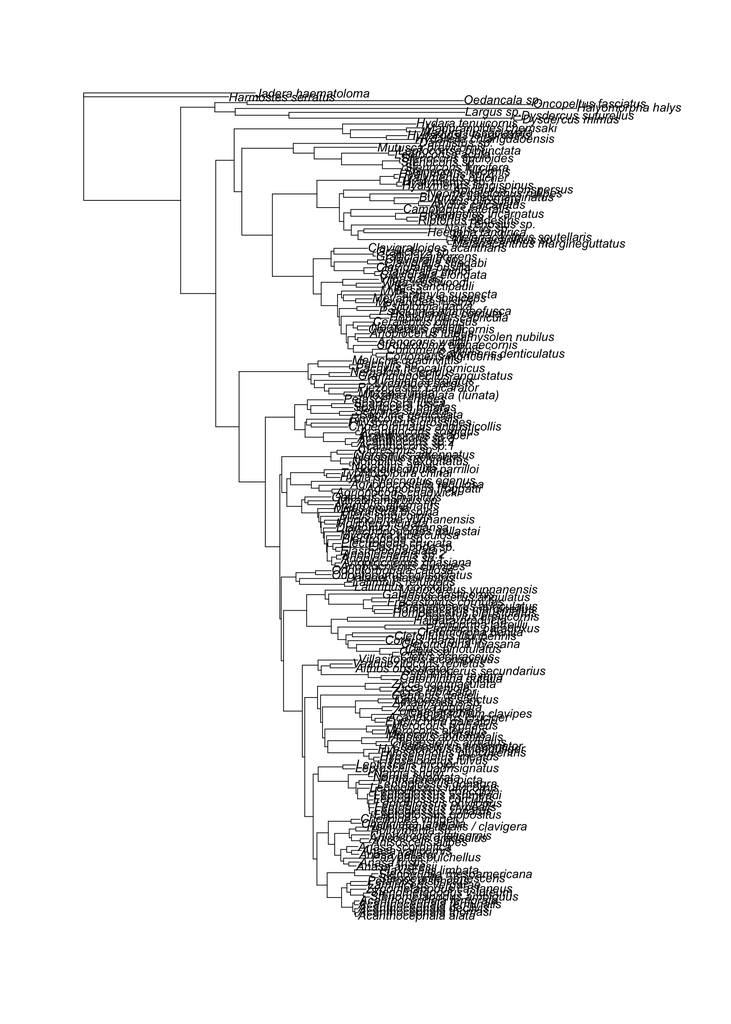

```r
t1 = root(tt, node = 308, resolve.root = T)

plot.phylo(ladderize(t1))
```

### ADULTS ANALYSES AT SPECIES LEVEL

```r
# REMOVING ZEROES FROM DATASET AND DROPPING UNNECESSARY TIPS ####

# Since our goal is analyzing trait evolution in Coreidae,
# we removed the non-Coreidae species in the tree.

# We also removed tips with no data or at species level,
# labeled as "0"

adults_data = sp_adults %>%
  filter(Antennae != 0,
         !Species_Name %in% c("Jadera_haematoloma", "Harmostes_serratus",
                              "Oedancala_sp.", "Oncopeltus_fasciatus",
                              "Largus_sp.", "Dysdercus_mimus",
                              "Dysdercus_suturellus", "Halyomorpha_halys"))
# Now we prune the tree to the data we have on Coreidae adults.

t_adults = keep.tip(t1, adults_data$Species_Name)
```

## THE MK MODEL: ASSESSING CHANGES IN ANTENNAL TRAIT STATE

Before running the analyses, we need to create a matrix so phytools can read our data.

```r
adults.sp.sim = setNames(as.factor(adults_data$Sum), adults_data$Species_Name)

adults.sp.sim
```

```
##            Acanthocephala_alata      Choerommatus_angusticollis
##                               3                               3
##              Tylocryptus_egenus            Typhlocolpura_chinai
##                               3                               3
##              Amorbus_alternatus              Gelonus_tasmanicus
##                               3                               3
##           Anoplocnemis_curvipes           Anoplocnemis_phasiana
##                               3                               3
##            Physomerus_grossipes                Elasmopoda_alata
##                               3                               3
##            Plectropoda_cruciata            Mygdonia_tuberculosa
##                               3                               3
##             Dianomictis_expansa               Molipteryx_lunata
##                               3                               3
##         Prionolomia_yunnanensis           Rhyticoris_terminalis
##                               3                               3
##              Mictis_longicornis             Pternistria_bispina
##                               3                               3
##                  Mictis_profana            Cloresmus_antennatus
##                               3                               3
##               Notobitus_affinis           Notobitus_sexguttatus
##                               3                               3
##             Notobitus_meleagris            Dalader_planiventris
##                               3                               4
##               Latimbus_concolor              Petascelis_remipes
##                               3                               3
##        Odontocurtus_consociatus           Odontorhopala_callosa
##                               3                               3
##       Cletoliturus_lituripennis              Cletomorpha_benita
##                               3                               3
##             Cletomorpha_nyasana              Cletus_binotulatus
##                               3                               3
##                Cletus_ochraceus               Coreus_marginatus
##                               3                               3
##              Sephina_geniculata             Pephricus_paradoxus
##                               3                               3
##             Tongorma_latreillii                Haidara_producta
##                               3                               3
##         Prionotylus_brevicornis           Fracastorius_cornutus
##                               3                               3
```

[output cut: 120 more lines]

```
##         Hydaropsis_longirostris             Madura_fuscoclavata
##                               3                               3
##           Maduranoides_chemsaki       Grammopoecilus_angustatus
##                               3                               3
##               Nematopus_lepidus                  Lycambes_sargi
##                               3                               3
##       Mozena_lineolata (lunata)                   Mozena_lurida
##                               3                               3
##          Piezogaster_calcarator             Ouranion_serrulatus
##                               3                               3
##            Melucha_quadrivittis        Pachylis_neocalifornicus
##                               3                               4
##          Agriopocoris_chadwicki          Agriopocoris_froggatti
##                               3                               3
## Levels: 3 4 5 6
```

With the matrix done, we can now move to the analyses.

We are using the fitMk function. The function requires us to specify the tree we are going to use, the data in matrix format, the evolutionary model, and, if we wish, the state of the root.

Lastly, we are using two types of root estimation. One where both states have equal probabilities, and another where probabilities are calculated based on the data (fitzjohn). We used both because we have no a priori hypothesis of the ancestral state.

```r
### NOTE: ONCE AGAIN I AM COMMENTING THE FUNCTION SO YOU DO NOT MISTAKENLY
### RUN IT. IF YOU WANT TO RUN IT, JUST UNCOMMENT THE FUNCTIONS.
### OTHERWISE, LOAD THEM AND CARRY ON WITH THE ANALYSES.

#fit.ER.equal = fitMk(ladderize(t_adults), adults.sp.sim , model = "ER",
#                     pi = 'equal')


#fit.ER.fitz = fitMk(ladderize(t_adults), adults.sp.sim , model = "ER",
#                    pi = 'fitzjohn')

#plot(fit.ER.fitz)

#save(fit.ER.equal, file = '~/Library/CloudStorage/OneDrive-Personal/Orientados/IC - Mariana/antennae-evol/coreidae_antennae/evo.models/er-equal-adults.RData')
#save(fit.ER.fitz, file = '~/Library/CloudStorage/OneDrive-Personal/Orientados/IC - Mariana/antennae-evol/coreidae_antennae/evo.models/er-fitz-adults.RData')

load( file = '~/Library/CloudStorage/OneDrive-Personal/Orientados/IC - Mariana/antennae-evol/coreidae_antennae/evo.models/er-equal-adults.RData')
load( file = '~/Library/CloudStorage/OneDrive-Personal/Orientados/IC - Mariana/antennae-evol/coreidae_antennae/evo.models/er-fitz-adults.RData')

# All rates differ model #

#fit.ARD.equal = fitMk(ladderize(t_adults), adults.sp.sim., model = "ARD",
#                      pi = 'equal')

#fit.ARD.fitz = fitMk(ladderize(t_adults), adults.sp.sim, model = "ARD",
#                     pi = 'fitzjohn')

#save(fit.ARD.equal, file = '~/Library/CloudStorage/OneDrive-Personal/Orientados/IC - Mariana/antennae-evol/coreidae_antennae/evo.models/ard-equal-adults.RData')
#save(fit.ARD.fitz, file = '~/Library/CloudStorage/OneDrive-Personal/Orientados/IC - Mariana/antennae-evol/coreidae_antennae/evo.models/ard-fitz-adults.RData')

load(file = '~/Library/CloudStorage/OneDrive-Personal/Orientados/IC - Mariana/antennae-evol/coreidae_antennae/evo.models/ard-equal-adults.RData')
load(file = '~/Library/CloudStorage/OneDrive-Personal/Orientados/IC - Mariana/antennae-evol/coreidae_antennae/evo.models/ard-fitz-adults.RData')

# We are also using the HRM models for thoroughness. Maybe there is an
# underlying mechanism for changing antennal state we are not capturing.

#fitHRM.er.equal = fitHRM(ladderize(t_adults), adults.sp.sim , model = "ER",
#                         pi = 'equal')

#fitHRM.er.fitz = fitHRM(ladderize(t_adults), adults.sp.sim , model = "ER",
#                        pi = 'fitzjohn')

#save(fitHRM.er.equal, file = '~/Library/CloudStorage/OneDrive-Personal/Orientados/IC - Mariana/antennae-evol/coreidae_antennae/evo.models/hrm-er-equal-adults.RData')
#save(fitHRM.er.fitz, file = '~/Library/CloudStorage/OneDrive-Personal/Orientados/IC - Mariana/antennae-evol/coreidae_antennae/evo.models/hrm-er-fitz-adultso.RData')

load(file = '~/Library/CloudStorage/OneDrive-Personal/Orientados/IC - Mariana/antennae-evol/coreidae_antennae/evo.models/hrm-er-equal-adults.RData')
load(file = '~/Library/CloudStorage/OneDrive-Personal/Orientados/IC - Mariana/antennae-evol/coreidae_antennae/evo.models/hrm-er-fitz-adults.RData')

# All rates differ HRM #

#fitHRM.equal = fitHRM(ladderize(t_adults), adults.sp.sim , model = "ARD",
#                      pi = 'equal')


#fitHRM.fitz = fitHRM(ladderize(t_adults), adults.sp.sim , model = "ARD",
#                     pi = 'fitzjohn')

#save(fitHRM.equal, file = '~/Library/CloudStorage/OneDrive-Personal/Orientados/IC - Mariana/antennae-evol/coreidae_antennae/evo.models/hrm-equal-adults.RData')
#save(fitHRM.fitz, file = '~/Library/CloudStorage/OneDrive-Personal/Orientados/IC - Mariana/antennae-evol/coreidae_antennae/evo.models/hrm-fitz-adults.RData')


load(file = '~/Library/CloudStorage/OneDrive-Personal/Orientados/IC - Mariana/antennae-evol/coreidae_antennae/evo.models/hrm-equal-adults.RData')
load(file = '~/Library/CloudStorage/OneDrive-Personal/Orientados/IC - Mariana/antennae-evol/coreidae_antennae/evo.models/hrm-fitz-adults.RData')

# Now we compare the models using AIC.
# We chose the model with the lowest AIC as the best model.
# If models had similar AICs, we chose the one with the lowest
# degrees of freedom. In the case, below, the ER model was the best.
# Between the two root states, we used the fitjohn approach because it
# had more AIC weight when compared to the equal ER model.

fit_models = anova(fit.ER.equal.ant, fit.ARD.equal.ant,
                    fitHRM.er.equal.ant, fitHRM.equal.ant,
                    fit.ER.fitz.ant, fit.ARD.fitz.ant,
                    fitHRM.er.fitz.ant, fitHRM.fitz.ant)
```

```
##                        log(L) d.f.       AIC       weight
## fit.ER.equal.ant    -44.46777    1  90.93554 1.535758e-01
## fit.ARD.equal.ant   -37.70006   12  99.40011 2.229796e-03
## fitHRM.er.equal.ant -43.69448    3  93.38896 4.503704e-02
## fitHRM.equal.ant    -36.44071   32 136.88141 1.619212e-11
## fit.ER.fitz.ant     -43.08195    1  88.16389 6.140157e-01
## fit.ARD.fitz.ant    -36.87588   12  97.75177 5.083916e-03
## fitHRM.er.fitz.ant  -42.30869    3  90.61738 1.800578e-01
## fitHRM.fitz.ant     -35.74081   32 135.48161 3.260369e-11
```

```r
# It was chosen the ER fitz model, once it had the lowest AIC with low
# degree of freedom = 1

anc.ant = ancr(fit.ER.fitz.ant)

fit.ER.fitz.ant
```

```
## Object of class "fitMk".
##
## Fitted (or set) value of Q:
##           3         4         5         6
## 3 -1.037626  0.345875  0.345875  0.345875
## 4  0.345875 -1.037626  0.345875  0.345875
## 5  0.345875  0.345875 -1.037626  0.345875
## 6  0.345875  0.345875  0.345875 -1.037626
##
## Fitted (or set) value of pi:
##        3        4        5        6
## 0.999766 0.000078 0.000078 0.000078
## due to treating the root prior as (a) nuisance.
##
## Log-likelihood: -43.081946
##
## Optimization method used was "nlminb"
##
## R thinks it has found the ML solution.
```

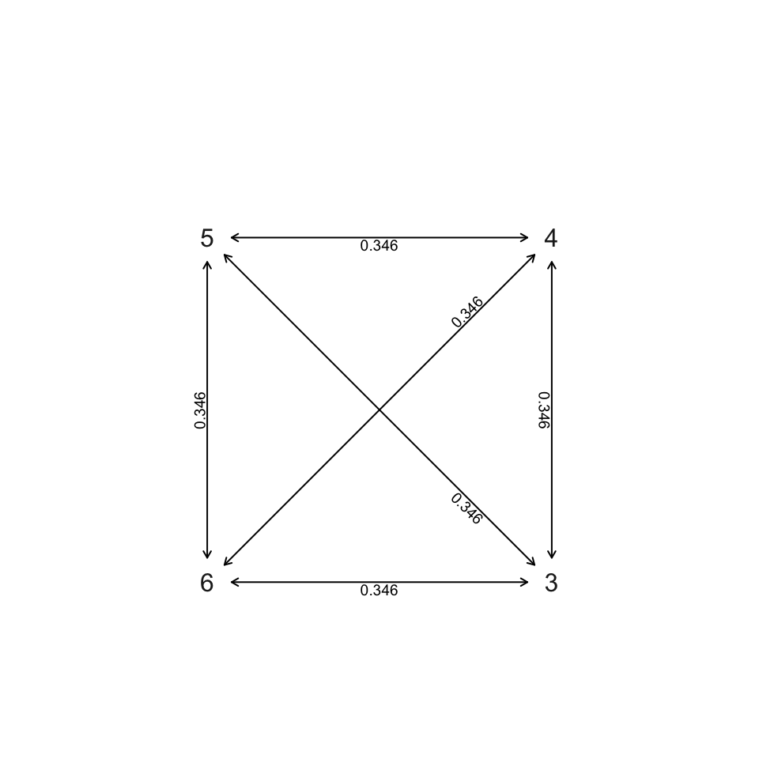

```r
plot(fit.ER.fitz.ant)
```

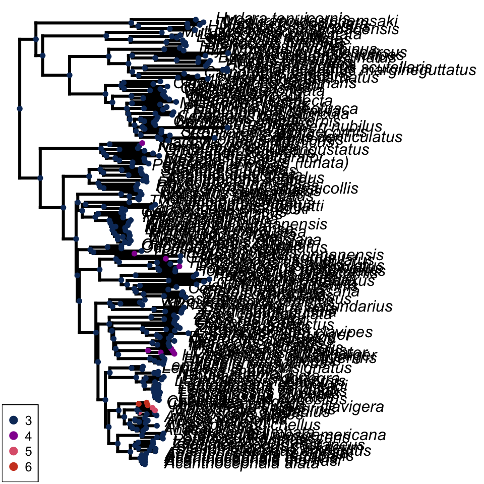

```r
cols = setNames(c("#0E3768","#94129F", "#de627a", "#ce4326"),
               levels(adults.sp.sim))


#pdf(file = './figures/ancestral-tree-adults-species.pdf', h = 24, w = 20)
plot(anc.ant,
     args.plotTree = list(lwd = 3, fsize = 1,
                          ftype = 'i',
                          outline = T,
                          cex = 0.2, offset = 1
     ),
     args.nodelabels = list(cex = 0.3, piecol = cols),
     args.tiplabels = list(cex = 0.3)

)
```

```r
#dev.off()
```

```r
ant_sim = make.simmap( tree = ladderize(t_adults), x= adults.sp.sim , model = "ER", pi = 'fitzjohn',
                     nsim = 1000)
```

```
## make.simmap is sampling character histories conditioned on
## the transition matrix
##
## Q =
##            3          4          5          6
## 3 -1.0376262  0.3458754  0.3458754  0.3458754
## 4  0.3458754 -1.0376262  0.3458754  0.3458754
## 5  0.3458754  0.3458754 -1.0376262  0.3458754
## 6  0.3458754  0.3458754  0.3458754 -1.0376262
## (estimated using likelihood);
## and (mean) root node prior probabilities
## pi =
##            3            4            5            6
## 9.997661e-01 7.803206e-05 7.794338e-05 7.794338e-05
```

```
## Done.
```

```r
#save(ant_sim, file = '~/Library/CloudStorage/OneDrive-Personal/Orientados/IC - #Mariana/antennae-evol/coreidae_antennae/evo.models/ant_sim.RData')

load(file = '~/Library/CloudStorage/OneDrive-Personal/Orientados/IC - Mariana/antennae-evol/coreidae_antennae/evo.models/ant_sim.RData')


sum_sim = describe.simmap(ant_sim)
sum_sim
```

```
## 1000 trees with a mapped discrete character with states:
##  3, 4, 5, 6
##
## trees have 8.248 changes between states on average
##
## changes are of the following types:
##        3,4   3,5   3,6   4,3   4,5   4,6   5,3   5,4   5,6   6,3   6,4   6,5
## x->y 4.963 1.746 1.052 0.032 0.004 0.006 0.339 0.039 0.003 0.019 0.037 0.008
##
## mean total time spent in each state is:
##              3          4           5          6    total
## raw  7.6808535 0.19879413 0.034137193 0.03682764 7.950612
## prop 0.9660707 0.02500362 0.004293656 0.00463205 1.000000
```

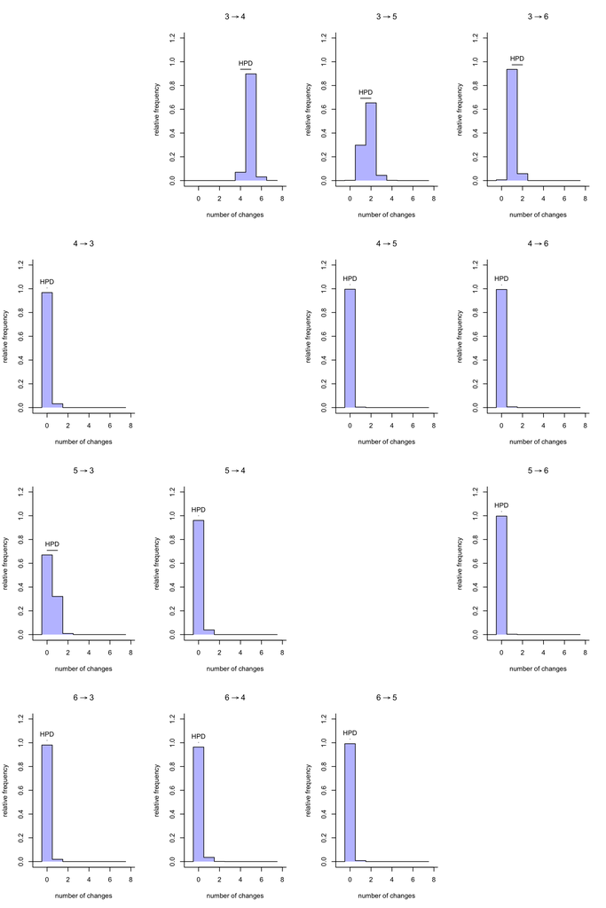

```r
plot(density(ant_sim))
```

### NYMPHS AND ADULTS GENERA ANALYSES

The same process made to antennomere analysis made for adults species will be made for nymphs and adults at the genus level

## NYMPHS

```r
# filtering data, removing 0 and species out of Coreidae

nymph_data = gen_nymphs%>%
  filter(Antennae != 0,
         !Species_Name %in% c("Jadera_haematoloma", "Harmostes_serratus",
                              "Oedancala_sp.", "Oncopeltus_fasciatus",
                              "Largus_sp.", "Dysdercus_mimus",
                              "Dysdercus_suturellus", "Halyomorpha_halys")) %>%
  mutate(Species_Name = case_when(
    Species_Name == "Holhymenia_tibialis" ~ "Holhymenia_tibialis / clavigera",
    TRUE ~ Species_Name
  ))

# Now we prune the tree to the data we have on Coreidae nymphs

t_nymphs = keep.tip(t1, nymph_data$Species_Name)


# Creating nymphs matrix so phytools can read our data

nymphs.gen.sim = setNames(as.factor(nymph_data$Sum), nymph_data$Species_Name)

nymphs.gen.sim
```

```
##         Acanthocephala_femorata           Acanthocoris_sordidus
##                               3                               3
##            Physomerus_grossipes              Petascelis_remipes
##                               3                               3
##                Sephina_subulata              Spartocera_batatas
##                               3                               3
##               Alydus_calcaratus          Neomegalotomus_rufipes
##                               3                               3
##            Apidaurus_conspersus             Camptopus_lateralis
##                               3                               3
##             Hamedius_incarnatus             Riptortus_pedestris
##                               3                               3
##              Heegeria_tangirica                    Nariscus_sp.
##                               3                               3
##               Melanacanthus_sp.                    Tenosius_sp.
##                               3                               3
##          Hyalymenus_longispinus              Arenocoris_waltlii
##                               3                               3
##              Bathysolen_nubilus         Coriomeris_denticulatus
##                               3                               3
##       Strobilotoma_typhaecornis        Ceraleptus_gracilicornis
##                               3                               3
##                 Clavigralla_sp.               Leptocorisa_acuta
##                               5                               3
##           Stenocoris_tipuloides             Mutusca_brevicornis
##                               3                               3
##             Madura_fuscoclavata               Nematopus_lepidus
##                               3                               3
##       Mozena_lineolata (lunata)          Piezogaster_calcarator
##                               3                               3
##             Ouranion_serrulatus            Melucha_quadrivittis
##                               3                               4
##        Pachylis_neocalifornicus          Agriopocoris_froggatti
##                               4                               3
##                       Hygia_sp.              Amorbus_alternatus
##                               3                               3
##              Mirabilamorbus_sp.              Gelonus_tasmanicus
##                               3                               3
##           Anoplocnemis_phasiana                  Elasmopoda_sp.
##                               3                               5
```

[output cut: 34 more lines]

```
##            Leptoscelis_tricolor             Paryphes_pulchellus
##                               3                               6
##                Anasa_varicornis                Anasa_scorbutica
##                               3                               5
##              Anisoscelis_alipes           Anisoscelis_gradadius
##                               4                               5
##          Chondrocera_laticornis Holhymenia_tibialis / clavigera
##                               5                               6
##             Chelinidea_tabulata             Chelinidea_vittiger
##                               5                               6
##             Plaxiscelis_limbata          Stenoeurilla_aenescens
##                               3                               3
##             Laminiceps_vergarae
##                               3
## Levels: 3 4 5 6
```

```r
# Model Mk, all models

#fit.ER.equal.nymph = fitMk(ladderize(t_nymphs), nymphs.gen.sim, model = "ER",
#                   pi = 'equal')


#fit.ER.fitz.nymph= fitMk(ladderize(t_nymphs), nymphs.gen.sim , model = "ER",
#                    pi = 'fitzjohn')

#save(fit.ER.equal.nymph, file = '~/Library/CloudStorage/OneDrive-Personal/Orientados/IC - Mariana/antennae-evol/coreidae_antennae/evo.models/er-equal-nymph.RData')
#save(fit.ER.fitz.nymph, file = '~/Library/CloudStorage/OneDrive-Personal/Orientados/IC - Mariana/antennae-evol/coreidae_antennae/evo.models/er-fitz-nymph.RData')

load( file = '~/Library/CloudStorage/OneDrive-Personal/Orientados/IC - Mariana/antennae-evol/coreidae_antennae/evo.models/er-equal-nymph.RData')
load( file = '~/Library/CloudStorage/OneDrive-Personal/Orientados/IC - Mariana/antennae-evol/coreidae_antennae/evo.models/er-fitz-nymph.RData')

#fit.ARD.equal.nymph = fitMk(ladderize(t_nymphs), nymphs.gen.sim , model = "ARD",
#                            pi = 'equal')

#fit.ARD.fitz.nymph = fitMk(ladderize(t_nymphs), nymphs.gen.sim, model = "ARD",
#                           pi = 'fitzjohn')

#save(fit.ARD.equal.nymph, file = '~/Library/CloudStorage/OneDrive-Personal/Orientados/IC - Mariana/antennae-evol/coreidae_antennae/evo.models/ARD-equal-nymph.RData')
#save(fit.ARD.fitz.nymph, file = '~/Library/CloudStorage/OneDrive-Personal/Orientados/IC - Mariana/antennae-evol/coreidae_antennae/evo.models//ARD-fitz-nymph.RData')

load( file = '~/Library/CloudStorage/OneDrive-Personal/Orientados/IC - Mariana/antennae-evol/coreidae_antennae/evo.models/ARD-equal-nymph.RData')
load( file = '~/Library/CloudStorage/OneDrive-Personal/Orientados/IC - Mariana/antennae-evol/coreidae_antennae/evo.models/ARD-fitz-nymph.RData')

# Hidden Rates Model, HRM

#fitHRM.er.equal.nymph = fitHRM(ladderize(t_nymphs), nymphs.gen.sim , model = "ER",
#                       pi = 'equal')

#fitHRM.er.fitz.nymph = fitHRM(ladderize(t_nymphs), nymphs.gen.sim , model = "ER",
#                              pi = 'fitzjohn')

#save(fitHRM.er.equal.nymph, file = '~/Library/CloudStorage/OneDrive-Personal/Orientados/IC - Mariana/antennae-evol/coreidae_antennae/evo.models/hrm-er-equal-nymph.RData')
#save(fitHRM.er.fitz.nymph, file = '~/Library/CloudStorage/OneDrive-Personal/Orientados/IC - Mariana/antennae-evol/coreidae_antennae/evo.models/hrm-er-fitz-nymph.RData')

load(file = '~/Library/CloudStorage/OneDrive-Personal/Orientados/IC - Mariana/antennae-evol/coreidae_antennae/evo.models/hrm-er-equal-nymph.RData')
load(file = '~/Library/CloudStorage/OneDrive-Personal/Orientados/IC - Mariana/antennae-evol/coreidae_antennae/evo.models/hrm-er-fitz-nymph.RData')

#fitHRM.ard.equal.nymph = fitHRM(ladderize(t_nymphs), nymphs.gen.sim , model = "ARD",
#                                pi = 'equal')


#fitHRM.ard.fitz.nymph = fitHRM(ladderize(t_nymphs), nymphs.gen.sim , model = "ARD",
#                         pi = 'fitzjohn')

#save(fitHRM.ard.equal.nymph, file = '~/Library/CloudStorage/OneDrive-Personal/Orientados/IC - Mariana/antennae-evol/coreidae_antennae/evo.models/hrm-equal-nymph.RData')
#save(fitHRM.ard.fitz.nymph, file = '~/Library/CloudStorage/OneDrive-Personal/Orientados/IC - Mariana/antennae-evol/coreidae_antennae/evo.models/hrm-fitz-nymph.RData')


load(file = '~/Library/CloudStorage/OneDrive-Personal/Orientados/IC - Mariana/antennae-evol/coreidae_antennae/evo.models/hrm-equal-nymph.RData')
load(file = '~/Library/CloudStorage/OneDrive-Personal/Orientados/IC - Mariana/antennae-evol/coreidae_antennae/evo.models/hrm-fitz-nymph.RData')

# comparing models
fit_models_nymphs = anova(fit.ER.equal.nymph, fit.ARD.equal.nymph,
                       fitHRM.er.equal.nymph, fitHRM.ard.equal.nymph,
                       fit.ER.fitz.nymph, fit.ARD.fitz.nymph,
                       fitHRM.er.fitz.nymph, fitHRM.ard.fitz.nymph)
```

```
##                           log(L) d.f.      AIC       weight
## fit.ER.equal.nymph     -79.22081    1 160.4416 1.156880e-05
## fit.ARD.equal.nymph    -64.73852   12 153.4770 3.763803e-04
## fitHRM.er.equal.nymph  -68.04855    3 142.0971 1.113662e-01
## fitHRM.ard.equal.nymph -63.04195   32 190.0839 4.232060e-12
## fit.ER.fitz.nymph      -77.84604    1 157.6921 4.574524e-05
## fit.ARD.fitz.nymph     -63.44250   12 150.8850 1.375579e-03
## fitHRM.er.fitz.nymph   -65.97372    3 137.9474 8.868246e-01
## fitHRM.ard.fitz.nymph  -61.83633   32 187.6727 1.413006e-11
```